# Twitter Analysis Menggunakan R - Studi Kasus Twitter Para Capres 2019

Hand-on Time

Raden Muhammad Hadi

2019-02-28

*Catatan*:

- Semua bagian di dalam teks *handout* ini dilakukan setelah membuat access token ke API twitter, jika belum silahkan baca *file powerpoint* yang diberikan
- Semua program dibawah ini dijalankan pada R versi 3.5.2, RStudio 1.1.456 dan pada sistem Operasi Linux 16.04 dan Windows 7. Jika ada perbedaan pada hasil yang diperoleh atau terdapat *error* ketika dijalankan mungkin dikarenakan perbedaan versi pada R maupun pada OS.

## Mempersiapkan Package

Pertama, *install* beberapa *package* berikut:

```r
install.packages("tidyverse") # Data Science Tool
install.packages("tidytext") # Untuk Text Mining dan Preprocessing
install.packages("rtweet") # Untuk akses ke Twitter API
install.packages("wordcloud2") # Untuk membuat wordcloud
install.packages("graphTweets") # Untuk membuat objek graph/network
install.packages("sigmajs") # Untuk memvisualisasikan graph/network
```

Setelah itu, panggil semua *package* dengan fungsi `library(nama_package)`:

```r
library(tidyverse) # Data Science Tool
library(tidytext) # Untuk Text Mining dan Preprocessing
library(rtweet) # Untuk akses ke Twitter API
```

```r
library(wordcloud2) # Untuk membuat wordcloud
library(graphTweets) # Untuk membuat objek graph/network
library(sigmajs) # Untuk memvisualisasikan graph/network
```

## Menggunakan access token untuk menggunakan Twitter API

Agar bisa mengakses API Twitter, kita perlu membuat *access token* yang sudah diperoleh melalui https://developer.twitter.com menggunakan fungsi `create_token()` dari *library* `rtweet` seperti berikut:

Untuk mengetahui fungsionalitas dan penggunaan lainnya dari `rtweet` bisa melihat dokumentasi pada https://rtweet.info/.

```r
create_token(app = "masukkan nama aplikasi",
             consumer_key = "masukkan consumer key",
             consumer_secret = "masukkan consumer secret",
             access_token = "masukkan access token",
             access_secret = "masukkan access secret")
```

Jalankan perintah diatas melalui *console* maupun *R script* sehingga muncul *output* berikut:

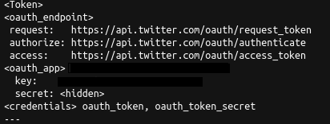

Keluaran fungsi `create_token()`

Setelah itu kita siap untuk melakukan *scrapping* data Twitter.

## Melihat Trending Topics Berdasarkan Negara

Kita bisa melihat berbagai daerah yang bisa dicari topiknya dengan menggunakan fungsi `trends_avalible()`:

```r
# Cari tren yang bisa diakses
trends_available()
```

```
## # A tibble: 467 x 8
##    name   url          parentid country  woeid countryCode  code place_type
##    <chr>  <chr>           <int> <chr>    <int> <chr>       <int> <chr>
##  1 World… http://wher…        0 ""           1 <NA>           19 Supername
##  2 Winni… http://wher… 23424775 Canada    2972 CA              7 Town
##  3 Ottawa http://wher… 23424775 Canada    3369 CA              7 Town
##  4 Quebec http://wher… 23424775 Canada    3444 CA              7 Town
##  5 Montr… http://wher… 23424775 Canada    3534 CA              7 Town
##  6 Toron… http://wher… 23424775 Canada    4118 CA              7 Town
##  7 Edmon… http://wher… 23424775 Canada    8676 CA              7 Town
##  8 Calga… http://wher… 23424775 Canada    8775 CA              7 Town
##  9 Vanco… http://wher… 23424775 Canada    9807 CA              7 Town
## 10 Birmi… http://wher… 23424975 United … 12723 GB              7 Town
## # … with 457 more rows
```

Kita bisa melihat *trending topics* saat ini menggunakan fungsi `get_trends("nama negara/daerah")`:

```r
# Dapatkan trending topics dari 'Indonesia'
get_trends("indonesia")
```

```
## # A tibble: 50 x 9
##    trend url   promoted_content query tweet_volume place  woeid
##    <chr> <chr> <lgl>            <chr>        <int> <chr>  <int>
##  1 #Caw… http… NA               %23C…           NA Indo… 2.34e7
##  2 #Ema… http… NA               %23E…           NA Indo… 2.34e7
##  3 #Ema… http… NA               %23E…        30053 Indo… 2.34e7
##  4 #DIY… http… NA               %23D…        11550 Indo… 2.34e7
##  5 Brun… http… NA               %22B…           NA Indo… 2.34e7
##  6 #BLA… http… NA               %23B…       127581 Indo… 2.34e7
##  7 Ratn… http… NA               %22R…           NA Indo… 2.34e7
##  8 Motif http… NA               Motif           NA Indo… 2.34e7
##  9 Madr… http… NA               Madr…       521550 Indo… 2.34e7
## 10 Sela… http… NA               %22S…           NA Indo… 2.34e7
## # … with 40 more rows, and 2 more variables: as_of <dttm>,
## #   created_at <dttm>
```

Kita bisa menyimpan hasilnya ke dalam sebuah variabel untuk analisis lebih lanjut, misalnya ke dalam variabel `trending_indo`:

```r
# Memasukkan nilai dari fungsi get_trends ke variabel trending_indo
trending_indo <- get_trends("indonesia")

# memanggil trending_indo
trending_indo
```

```
## # A tibble: 50 x 9
##    trend url   promoted_content query tweet_volume place  woeid
##    <chr> <chr> <lgl>            <chr>        <int> <chr>  <int>
##  1 #Caw… http… NA               %23C…           NA Indo… 2.34e7
##  2 #Ema… http… NA               %23E…           NA Indo… 2.34e7
##  3 #Ema… http… NA               %23E…        29268 Indo… 2.34e7
##  4 #DIY… http… NA               %23D…        11367 Indo… 2.34e7
##  5 #BLA… http… NA               %23B…       126206 Indo… 2.34e7
##  6 Brun… http… NA               %22B…           NA Indo… 2.34e7
##  7 Ratn… http… NA               %22R…           NA Indo… 2.34e7
##  8 Madr… http… NA               Madr…       521068 Indo… 2.34e7
##  9 Sela… http… NA               %22S…           NA Indo… 2.34e7
## 10 Hote… http… NA               %22H…           NA Indo… 2.34e7
## # … with 40 more rows, and 2 more variables: as_of <dttm>,
## #   created_at <dttm>
```

Kita bisa melihat berbagai fitur yang terdapat dalam variabel tersebut dengan menggunakan fungsi `glimpse()` dari *library* `dplyr` dan *pipe operator* %>% dari *library* `magrittr`:

`dplyr` dan `magritrr` adalah bagian dari satu *library* besar yaitu `tidyverse` yang bisa dipelajari lebih lanjut melalui https://www.tidyverse.org/

```r
# Dari trending_indo
trending_indo %>%
  # Lihat struktur data keseluruhan
  glimpse()
```

```
## Observations: 50
## Variables: 9
## $ trend            <chr> "#CawapresGueKeren", "#Emak2KorbanRezimJKW", "#…
## $ url              <chr> "http://twitter.com/search?q=%23CawapresGueKere…
## $ promoted_content <lgl> NA, NA, NA, NA, NA, NA, NA, NA, NA, NA, NA, NA,…
## $ query            <chr> "%23CawapresGueKeren", "%23Emak2KorbanRezimJKW"…
## $ tweet_volume     <int> NA, NA, 29268, 11367, 126206, NA, NA, 521068, N…
## $ place            <chr> "Indonesia", "Indonesia", "Indonesia", "Indones…
## $ woeid            <int> 23424846, 23424846, 23424846, 23424846, 2342484…
## $ as_of            <dttm> 2019-02-28 04:24:22, 2019-02-28 04:24:22, 2019…
## $ created_at       <dttm> 2019-02-28 04:16:14, 2019-02-28 04:16:14, 2019…
```

Penjelasan sebagian isi kolom:

- Kolom `trend` berisi tren yang saat ini ada/muncul di daerah Indonesia
- Kolom `url` berisi alamat *url* terkait *trending topics* yang dilihat
- Kolom `tweet_volume` berisis jumlah banyaknya topik/*hashtag* tersebut digunakan oleh pengguna twitter
- Kolom `place` dan `woeid` adalah negara dan id negara dimana *trending topics* diperoleh
- Kolom `created_at` adalah waktu kapan *trending topics* tersebut muncul

Kita bisa memilih beberapa variabel diatas dengan menggunakan fungsi `select(nama_kolom)`:

```r
# Dari trending_indo
trending_indo %>%
  # pilih kolom trend dan kolom tweet_volume
  select(trend, tweet_volume)
```

```
## # A tibble: 50 x 2
##    trend                          tweet_volume
##    <chr>                                 <int>
##  1 #CawapresGueKeren                        NA
##  2 #Emak2KorbanRezimJKW                     NA
##  3 #Emak2Korban02                        29268
##  4 #DIYogyakartaPilihPrabowoSandi        11367
##  5 #BLACKPINKxBILLBOARD                 126206
##  6 Bruno Mars                               NA
##  7 Ratna Sarumpaet                          NA
##  8 Madrid                               521068
##  9 Selamat Hari Gizi Nasional               NA
## 10 Hotel Sultan                             NA
## # … with 40 more rows
```

Hasil yang dikeluarkan di *console* cenderung lebih ringkas karena struktur data yang digunakan adalah *tible*, sehingga keluaran yang diperlihatkan paling banyak hanya 10 baris. Kita bisa mengatur banyak keluaran yang ingin dimunculkan pada *console* dengan menggunakan fungsi `print(n = banyak_keluaran)`:

```r
# Dari trending_indo
trending_indo %>%
  # pilih kolom trend dan kolom tweet_volume
  select(trend, tweet_volume) %>%
  # perlihatkan sebanyak 100 baris
  print(n = 100)
```

```
## # A tibble: 50 x 2
##    trend                          tweet_volume
##    <chr>                                 <int>
##  1 #CawapresGueKeren                        NA
##  2 #Emak2KorbanRezimJKW                     NA
##  3 #Emak2Korban02                        29268
##  4 #DIYogyakartaPilihPrabowoSandi        11367
##  5 #BLACKPINKxBILLBOARD                 126206
##  6 Bruno Mars                               NA
##  7 Ratna Sarumpaet                          NA
##  8 Madrid                               521068
##  9 Selamat Hari Gizi Nasional               NA
## 10 Hotel Sultan                             NA
## 11 Barca                                252454
## 12 West Java                                NA
```

[output cut: 38 more lines]

Dapat dilihat bahwa ternyata terdapat beberapa `trend` yang tidak memiliki `tweet_volume` atau bernilai NA. Kita bisa mengeliminasi nilai NA dengan menggunakan fungsi `filter()`:

```r
# Dari trending_indo
trending_indo %>%
  # pilih kolom trend dan kolom tweet_volume
  select(trend, tweet_volume) %>%
  # filter kolom tweet_volume dimana nilainya tidak boleh 'NA'
  filter(tweet_volume != "NA")
```

```
## # A tibble: 20 x 2
##    trend                          tweet_volume
##    <chr>                                 <int>
##  1 #Emak2Korban02                        29268
##  2 #DIYogyakartaPilihPrabowoSandi        11367
##  3 #BLACKPINKxBILLBOARD                 126206
##  4 Madrid                               521068
##  5 Barca                                252454
##  6 Van Dijk                              21021
##  7 Trippier                              28585
##  8 Suarez                               166627
##  9 Solari                                25688
## 10 Bernabeu                             145849
## 11 Ozil                                  26335
## 12 Luna Maya                             13965
## 13 #PrabowoTumbalinRatna                 12148
## 14 #ElClásico                           176587
## 15 #2019GantiPresiden                    75487
## 16 #SyahriniReinoSatuAtap                51806
## 17 #17April2019GantiPresiden             42294
## 18 #PrabowoAja                           56714
## 19 #ThePowerOfEmakEmak                   69841
## 20 #BBHPrivéLA                          270565
```

Jika dilihat, nilai NA sudah tidak ada lagi. Selanjutnya kita ingin melihat tren mana yang memiliki volume terbesar dengan menggunakan fungsi `arrange()` dan menggunakan fungsi `desc()` untuk mengurutkan data berdasarkan kolom tertentu:

```r
# Dari trending_indo
trending_indo %>%
  # pilih kolom trend dan kolom tweet_volume
  select(trend, tweet_volume) %>%
  # filter kolom tweet_volume dimana nilainya tidak boleh 'NA'
  filter(tweet_volume != "NA") %>%
  # disusun berdasarkan tweet_volume secara descending
  arrange(desc(tweet_volume))
```

```
## # A tibble: 20 x 2
##    trend                          tweet_volume
##    <chr>                                 <int>
##  1 Madrid                               521068
##  2 #BBHPrivéLA                          270565
##  3 Barca                                252454
##  4 #ElClásico                           176587
##  5 Suarez                               166627
##  6 Bernabeu                             145849
##  7 #BLACKPINKxBILLBOARD                 126206
##  8 #2019GantiPresiden                    75487
##  9 #ThePowerOfEmakEmak                   69841
## 10 #PrabowoAja                           56714
## 11 #SyahriniReinoSatuAtap                51806
## 12 #17April2019GantiPresiden             42294
## 13 #Emak2Korban02                        29268
## 14 Trippier                              28585
## 15 Ozil                                  26335
## 16 Solari                                25688
## 17 Van Dijk                              21021
## 18 Luna Maya                             13965
## 19 #PrabowoTumbalinRatna                 12148
## 20 #DIYogyakartaPilihPrabowoSandi        11367
```

Selanjutnya, kita bisa membuat wordcloud dengan menggunakan fungsi `wordcloud()` dari *library* `wordcloud2`:

dokumentasi terkait wordcloud2 beserta contohnya dapat dilihat pada [*link* berikut](https://cran.r-project.org/web/packages/wordcloud2/vignettes/wordcloud.html) atau bisa mengunjungi [*r-graph gallery*](https://www.r-graph-gallery.com/the-wordcloud2-library/).

```r
# Dari trending_indo
trending_indo %>%
  # pilih kolom trend dan kolom tweet_volume
  select(trend, tweet_volume) %>%
  # filter kolom tweet_volume dimana nilainya tidak boleh 'NA'
  filter(tweet_volume != "NA") %>%
  # disusun berdasarkan tweet_volume secara descending
  arrange(desc(tweet_volume)) %>%
  # buat wordcloud dengan ukuran huruf 2
  wordcloud2(size = 2)
```

[interactive chart not shown]

## Analisa Tweet Berdasarkan Hashtag, Mention atau Keyword

Kita bisa melakukan pencarian untuk topik tertentu berdasarkan hashtag, mention maupun kata kunci apapun menggunakan fungsi `search_tweet`. Sebagai contoh saya mencari hashtag **#rstats**:

```r
# Cari tweet dengan hashtag #rstats sebanyak 100 lalu masukkan ke variabel 'hasil_pencarian'
hasil_pencarian <- search_tweets(q = "#rstats", n = 100)
```

```
## Searching for tweets...
```

```
## Finished collecting tweets!
```

```r
# perlihatkan nilai dari hasil_pencarian
hasil_pencarian
```

```
## # A tibble: 100 x 88
##    user_id status_id created_at          screen_name text  source
##    <chr>   <chr>     <dttm>              <chr>       <chr> <chr>
##  1 701540… 11009748… 2019-02-28 04:23:50 fatma_cina… "Gel… Twitt…
##  2 240847… 11009743… 2019-02-28 04:21:44 SamStiyer   "Gre… Twitt…
##  3 973888… 11009742… 2019-02-28 04:21:33 PD_MobileA… "Tec… Twitt…
##  4 901509… 11009740… 2019-02-28 04:20:51 electivenow "Mul… Twitt…
##  5 904618… 11009739… 2019-02-28 04:20:10 VuePackage  "Tec… VuePa…
##  6 188811… 11009734… 2019-02-28 04:18:22 jsonbaik    "Gre… Twitt…
##  7 162410… 11009731… 2019-02-28 04:17:11 HydrePrever "Pyt… Twitt…
##  8 192103… 11009728… 2019-02-28 04:16:03 Dlobdog     "Tec… Twitt…
##  9 172276… 11009726… 2019-02-28 04:14:57 MattDabrow… "Ove… Twitt…
## 10 737164… 11009720… 2019-02-28 04:12:57 christineb… "Tod… Twitt…
## # … with 90 more rows, and 82 more variables: display_text_width <dbl>,
## #   reply_to_status_id <lgl>, reply_to_user_id <lgl>,
## #   reply_to_screen_name <lgl>, is_quote <lgl>, is_retweet <lgl>,
## #   favorite_count <int>, retweet_count <int>, hashtags <list>,
## #   symbols <list>, urls_url <list>, urls_t.co <list>,
## #   urls_expanded_url <list>, media_url <list>, media_t.co <list>,
## #   media_expanded_url <list>, media_type <list>, ext_media_url <list>,
## #   ext_media_t.co <list>, ext_media_expanded_url <list>,
## #   ext_media_type <chr>, mentions_user_id <list>,
## #   mentions_screen_name <list>, lang <chr>, quoted_status_id <chr>,
## #   quoted_text <chr>, quoted_created_at <dttm>, quoted_source <chr>,
## #   quoted_favorite_count <int>, quoted_retweet_count <int>,
## #   quoted_user_id <chr>, quoted_screen_name <chr>, quoted_name <chr>,
## #   quoted_followers_count <int>, quoted_friends_count <int>,
## #   quoted_statuses_count <int>, quoted_location <chr>,
## #   quoted_description <chr>, quoted_verified <lgl>,
## #   retweet_status_id <chr>, retweet_text <chr>,
## #   retweet_created_at <dttm>, retweet_source <chr>,
## #   retweet_favorite_count <int>, retweet_retweet_count <int>,
## #   retweet_user_id <chr>, retweet_screen_name <chr>, retweet_name <chr>,
## #   retweet_followers_count <int>, retweet_friends_count <int>,
## #   retweet_statuses_count <int>, retweet_location <chr>,
## #   retweet_description <chr>, retweet_verified <lgl>, place_url <chr>,
## #   place_name <chr>, place_full_name <chr>, place_type <chr>,
## #   country <chr>, country_code <chr>, geo_coords <list>,
## #   coords_coords <list>, bbox_coords <list>, status_url <chr>,
## #   name <chr>, location <chr>, description <chr>, url <chr>,
## #   protected <lgl>, followers_count <int>, friends_count <int>,
## #   listed_count <int>, statuses_count <int>, favourites_count <int>,
## #   account_created_at <dttm>, verified <lgl>, profile_url <chr>,
## #   profile_expanded_url <chr>, account_lang <chr>,
## #   profile_banner_url <chr>, profile_background_url <chr>,
## #   profile_image_url <chr>
```

Kita bisa melihat struktur data dari `hasil_pencarian` dengan menggunakan `glimpse()`:

```r
# Dari variabel hasil_pencarian
hasil_pencarian %>%
  # perlihatkan struktur data
  glimpse()
```

```
## Observations: 100
## Variables: 88
## $ user_id                 <chr> "701540016", "2408471545", "973888390050…
## $ status_id               <chr> "1100974835843383299", "1100974305431769…
## $ created_at              <dttm> 2019-02-28 04:23:50, 2019-02-28 04:21:4…
## $ screen_name             <chr> "fatma_cinar_ftm", "SamStiyer", "PD_Mobi…
## $ text                    <chr> "Geleceğin Mesleği: Büyük Verinin Analiz…
## $ source                  <chr> "Twitter for iPhone", "Twitter for iPhon…
## $ display_text_width      <dbl> 277, 140, 140, 140, 140, 185, 269, 140, …
## $ reply_to_status_id      <lgl> NA, NA, NA, NA, NA, NA, NA, NA, NA, NA, …
## $ reply_to_user_id        <lgl> NA, NA, NA, NA, NA, NA, NA, NA, NA, NA, …
## $ reply_to_screen_name    <lgl> NA, NA, NA, NA, NA, NA, NA, NA, NA, NA, …
## $ is_quote                <lgl> FALSE, FALSE, FALSE, FALSE, FALSE, FALSE…
## $ is_retweet              <lgl> FALSE, TRUE, TRUE, TRUE, TRUE, FALSE, FA…
## $ favorite_count          <int> 1, 0, 0, 0, 0, 1, 0, 0, 0, 0, 0, 0, 0, 0…
```

[output cut: 75 more lines]

Untuk sekali pemanggilan, terdapat 88 variabel dengan diantaranya:

- `user_id` (tipe data: `character`) merupakan ID dari pengguna Twitter
- `status_id` (tipe data: `character`) merupakan ID dari status pengguna
- `created_at` (tipe data: `date-time`) merupakan informasi terkait kapan status tersebut dibuat
- `screen_name` (tipe data: `character`) merupakan nama dari pengguna Twitter
- `text` (tipe data: `character`) merupakan status/*tweet* dari pengguna Twitter berdasarkan user tertentu
- `display_text_width` (tipe data: `double`) merupakan panjang kata dari *tweet* yang dikirimkan
- `mentions_screen_name` (tipe data: `list`) merupakan nama dari user yang di-*mention* pada teks
- `profile_image_url` (tipe data: `character`) merupakan *link* dari profil pengguna

Kita juga bisa melakukan pencarian dengan menggunakan kata kunci (*keyword*), misalnya kata ‘politik’ dengan tweet berbahasa indonesia sebanyak 3200:

```r
# Cari tweet dengan kata kunci 'politik' sebanyak 3200 tweet lalu masukkan ke variabel 'hasil_pencarian2' dengan bahasa yang dipakai adalah bahasa indonesia
hasil_pencarian2 <- search_tweets(q = "politik", n = 3200, lang = "id")
```

```
## Searching for tweets...
```

```
## Finished collecting tweets!
```

```r
# perlihatkan nilai dari hasil_pencarian2
hasil_pencarian2
```

```
## # A tibble: 3,117 x 88
##    user_id status_id created_at          screen_name text  source
##    <chr>   <chr>     <dttm>              <chr>       <chr> <chr>
##  1 116787… 11009748… 2019-02-28 04:24:05 nyinyir_ba… Dedi… Twitt…
##  2 788978… 11009748… 2019-02-28 04:24:04 diditjunai… "✅Pa… Twitt…
##  3 788978… 11009676… 2019-02-28 03:55:27 diditjunai… "Tak… Twitt…
##  4 867438… 11009748… 2019-02-28 04:24:03 KholidZaif… Ratn… dlvr.…
##  5 106060… 11009748… 2019-02-28 04:24:02 imunk_wae   "Ema… Twitt…
##  6 216161… 11009748… 2019-02-28 04:24:01 hrs_bkd     "Pak… Twitt…
##  7 609616… 11009748… 2019-02-28 04:24:01 ryanadsty   Hidu… Twitt…
##  8 828144… 11009748… 2019-02-28 04:24:01 muSlimATjkt "Kat… Twitt…
##  9 235168… 11009748… 2019-02-28 04:24:00 ysminsuraya "Tak… Twitt…
## 10 331481… 11009744… 2019-02-28 04:22:25 NissaLatte  Dari… Twitt…
## # … with 3,107 more rows, and 82 more variables: display_text_width <dbl>,
## #   reply_to_status_id <chr>, reply_to_user_id <chr>,
## #   reply_to_screen_name <chr>, is_quote <lgl>, is_retweet <lgl>,
## #   favorite_count <int>, retweet_count <int>, hashtags <list>,
## #   symbols <list>, urls_url <list>, urls_t.co <list>,
## #   urls_expanded_url <list>, media_url <list>, media_t.co <list>,
## #   media_expanded_url <list>, media_type <list>, ext_media_url <list>,
## #   ext_media_t.co <list>, ext_media_expanded_url <list>,
## #   ext_media_type <chr>, mentions_user_id <list>,
## #   mentions_screen_name <list>, lang <chr>, quoted_status_id <chr>,
## #   quoted_text <chr>, quoted_created_at <dttm>, quoted_source <chr>,
## #   quoted_favorite_count <int>, quoted_retweet_count <int>,
## #   quoted_user_id <chr>, quoted_screen_name <chr>, quoted_name <chr>,
## #   quoted_followers_count <int>, quoted_friends_count <int>,
## #   quoted_statuses_count <int>, quoted_location <chr>,
## #   quoted_description <chr>, quoted_verified <lgl>,
## #   retweet_status_id <chr>, retweet_text <chr>,
## #   retweet_created_at <dttm>, retweet_source <chr>,
## #   retweet_favorite_count <int>, retweet_retweet_count <int>,
## #   retweet_user_id <chr>, retweet_screen_name <chr>, retweet_name <chr>,
## #   retweet_followers_count <int>, retweet_friends_count <int>,
## #   retweet_statuses_count <int>, retweet_location <chr>,
## #   retweet_description <chr>, retweet_verified <lgl>, place_url <chr>,
## #   place_name <chr>, place_full_name <chr>, place_type <chr>,
## #   country <chr>, country_code <chr>, geo_coords <list>,
## #   coords_coords <list>, bbox_coords <list>, status_url <chr>,
## #   name <chr>, location <chr>, description <chr>, url <chr>,
## #   protected <lgl>, followers_count <int>, friends_count <int>,
## #   listed_count <int>, statuses_count <int>, favourites_count <int>,
## #   account_created_at <dttm>, verified <lgl>, profile_url <chr>,
## #   profile_expanded_url <chr>, account_lang <chr>,
## #   profile_banner_url <chr>, profile_background_url <chr>,
## #   profile_image_url <chr>
```

*Catatan*: Terkadang *tweet* yang diperoleh tidak selalu sama dengan jumlah maksimal, jika ingin mengambil lebih dari 3200 maka harus menggunakan parameter `retryonratelimit = TRUE`.

Selanjutnya kita juga dapat melihat frekuensi *keyword* tersebut digunakan menggunakan fungsi `ts_plot()`:

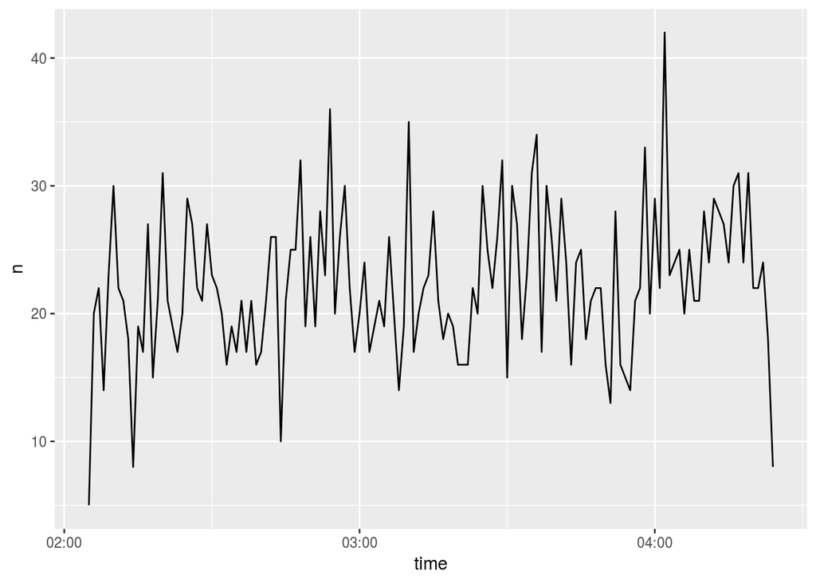

```r
# Dari hasil pencarian
hasil_pencarian2 %>%
  # buatkan grafik time-series frekuensi kata kunci tersebut
  # dipakai dalam tweet per menit
  ts_plot(by = "minutes")
```

Kita bisa mengganti nilai dari parameter `by` dengan `seconds`, `minutes`, `hours`, `days`, `weeks`, bahkan dengan keterangan waktu semisal `3 seconds`, `3 days` dan lainnya.

Sepertinya hasil plot kurang menarik. Kita bisa menambahkan judul dan memperbaiki tema dari grafiknya dengan menggunakan beberapa fungsi dari `ggplot2` seperti berikut:

Dokumentasi terkait `ggplot2` dapat dilihat pada situs https://ggplot2.tidyverse.org/.

[figure not shown]

```r
# Dari hasil pencarian
hasil_pencarian2 %>%
  # buatkan grafik time-series frekuensi
  # kata kunci tersebut dipakai dalam
  # tweet per menit
  ts_plot(by = "minutes") +
  # Menggunakan theme_minimal
  theme_minimal() +
  # Memberikan judul plot dengan
  # elemen teks tebal (bold)
  theme(plot.title = element_text(face = "bold")) +
  # Menambahkan beberapa elemen
  labs(
    # Berikan label untuk x
    x = "waktu dalam menit",
    # Berikan label untuk y
    y = "frekuensi",
    # Berikan judul
    title = "Frekuensi Tweet dengan kata Kunci 'Politik'",
    # Memberi sub-judul
    subtitle = "per menit",
    # Memberi caption
    caption = paste0("Sumber: Twitter, tanggal: ", Sys.Date())
  )
```

Selanjutnya kita akan melihat semua *tweet* tersebut dengan melihat variabel `text`:

```r
# Dari hasil_pencarian2
hasil_pencarian2 %>%
  # Pilih kolom teks
  select(text)
```

```
## # A tibble: 3,117 x 1
##    text
##    <chr>
##  1 Dedikasi ibu Ratna sarumpaet hancur karena politik hoax #Emak2Korban02 …
##  2 "✅Para Suami/Bapak.\nIngat kan istri untuk berhati hati kalau ada ajaka…
##  3 "Tak akan terjadi 😉\nMamakke sdh teredukasi cukup baik tntg politik di …
##  4 Ratna Sarumpaet: Ada Ketegangan Luar Biasa Saat Penyidikan, Ini Politik…
##  5 "Emak emak gk bakalan hirau dgn politik kalo keadaan baik2 saja, ini mh…
##  6 "Pakar LIPI : ''Ada beberapa data saat debat yang disebutkan Jokowi kel…
##  7 Hidup, milenial! https://t.co/Cdsism6qQG
##  8 "Kata orang, tidak ada kebetulan dalam Politik\n\nSaya setuju https://t…
##  9 "Tak sensitif langsung kepada perasaan keluarga Arwah.  \nBukan semua p…
## 10 Daripada harus susah-susah mengabdi untuk partai politik, lebih baik la…
## # … with 3,107 more rows
```

Jika dilihat, terdapat beberapa teks yang mengandung *hashtag* (#), *link*, *mention* (@) dan kadangkala terdapat teks yang memuat *emoticon*. Hal ini bisa dibersihkan dengan menggunakan fungsi `mutate`, `gsub()` dan `plain_tweets()`:

```r
# Dari hasil_pencarian2
hasil_pencarian2 %>%
  # Pilih kolom text
  select(text) %>%
  # Ubah elemen pada kolom text dengan mengganti
  # semua link dengan karakter kosong
  mutate(text = gsub(pattern = "http\\S+",
                     replacement = "",
                     x = text)) %>%
  # Ubah elemen pada kolom text dengan mengganti
  # semua hashtag dengan karakter kosong
  mutate(text = gsub(pattern = "#",
                     replacement = "",
                     x = text)) %>%
  # Ubah elemen pada kolom text dengan mengganti
  # semua mention dengan karakter kosong
  mutate(text = gsub(pattern = "@",
                     replacement = "",
                     x = text)) %>%
  # Bersihkan karakter lainnya (contoh: emoticon)
  # lalu simpan ke dalam variabel text_cleaned
  plain_tweets() -> text_cleaned
```

**Catatan**:

- Ada 3 jenis operator *assignment* di R, yaitu `<-`, `=`, dan `->`. Operator `<-` dan `=` memiliki fungsi yang sama yaitu memasukkan nilai dari sebelah kanan operator ke variabel (contoh: `nilai <- 3` atau `nilai = 3`), sedangkan `->` memasukkan nilai dari sebelah kiri operator ke variabel (contoh: `3 -> nilai`)

Selanjutnya kita akan melihat wordcloud dari teks yang sudah dibersihkan dengan memotongnya menjadi per kata dengan fungsi `unnest_tokens()` dan menghitung frekuensu huruf dengan fungsi `count()`:

fungsi `unnest_tokens()` dan `count()` adalah bagian dari `tidytext`. Referensi terkait `tidytext` dapat melihat situs https://www.tidytextmining.com/.

```r
# Dari variabel text_cleaned
text_cleaned %>%
  # tokenize setiap kalimat menjadi per kata
  unnest_tokens(input = text, output = token) %>%
  # hitung frekuensi semua huruf lalu urutkan
  # dari yang paling besar frekuensinya
  count(token, sort = T)
```

```
## # A tibble: 6,654 x 2
##    token       n
##    <chr>   <int>
##  1 politik  3098
##  2 dan      1320
##  3 yang     1097
##  4 di       1020
##  5 emak     1018
##  6 saya      770
##  7 tidak     757
##  8 yg        702
##  9 ini       663
## 10 ada       568
## # … with 6,644 more rows
```

Jika diperhatikan, terdapat kata-kata seperti kata ‘ini’, ‘di’, ‘dari’, ‘itu’ dan kata-kata lainnya yang tidak memiliki makna atau memuat topik tertentu di dalam sebuah teks, kata-kata ini biasa disebut sebagai *stopwords*. *Stopwords* dapat dihilangkan dengan mudah selama kita memiliki korpus terkait *stopwords*. Korpus ini bisa kita buat sendiri atau menggunakan yang sudah ada seperti yang bisa diperoleh dari [github masdevid berikut](https://raw.githubusercontent.com/masdevid/ID-Stopwords/master/id.stopwords.02.01.2016.txt) dengan menyalin *link* github tersebut lalu masukkan ke dalam fungsi `read_csv()` agar korpus tersebut bisa diambil:

Korpus (*corpus*) adalah koleksi teks yang besar dan terstruktur. Biasanya digunakan untuk analisa statistik dan pengujian hipotesis

```r
# Ambil stopwords dari link, beri nama kolomnya 'stopwords'
# hasilnya disimpan ke dalam variabel 'stopword_indo'
stopword_indo <- read_csv("https://raw.githubusercontent.com/masdevid/ID-Stopwords/master/id.stopwords.02.01.2016.txt",
                          col_names = "stopwords")
# Melihat sebagian isi dari stopword_indo
stopword_indo
```

```
## # A tibble: 758 x 1
##    stopwords
##    <chr>
##  1 ada
##  2 adalah
##  3 adanya
##  4 adapun
##  5 agak
##  6 agaknya
##  7 agar
##  8 akan
##  9 akankah
## 10 akhir
## # … with 748 more rows
```

Selanjutnya kita akan membuang semua *stopwords* pada teks dengan menggunakan fungsi `anti_join()`:

```r
# Dari variabel text_cleaned
text_cleaned %>%
  # tokenize setiap kalimat menjadi per kata
  unnest_tokens(input = text, output = token) %>%
  # buang setiap stopword yang ada pada kolom
  # token jika terdapat kata yang sama dengan
  # yang ada pada variabel stopword_indo
  anti_join(stopword_indo, by = c("token" = "stopwords"))
```

```
## # A tibble: 55,065 x 1
##    token
##    <chr>
##  1 dedikasi
##  2 ratna
##  3 sarumpaet
##  4 hancur
##  5 politik
##  6 hoax
##  7 emak2korban02
##  8 suami
##  9 istri
## 10 berhati
## # … with 55,055 more rows
```

Dapat dilihat bahwa beberapa *stopwords* sudah dihilangkan walaupun masih terdapat kata seperti ‘yg’, ‘ya’, ‘nih’ dan kata-kata lainnya yang harusnya tidak perlu ada. Hal ini bisa diantisipasi dengan melengkapi korpus yang sudah ada. Misalnya menyimpan korpus tersebut ke dalam *file* CSV lalu melengkapi korpusnya melalui Excel atau program *spreadsheet* lainnya yang lebih mudah digunakan.

Selanjutnya kita akan mencoba membuat wordcloud dari teks yang sudah dibersihkan dari *stopwords*:

```r
# Dari variabel text_cleaned
text_cleaned %>%
  # tokenize setiap kalimat menjadi per kata
  unnest_tokens(input = text, output = token) %>%
  # buang setiap stopword yang ada pada kolom
  # token jika terdapat kata yang sama dengan
  # yang ada pada variabel stopword_indo
  anti_join(stopword_indo, by = c("token" = "stopwords")) %>%
  # Hitung frekuensi huruf lalu urutkan dari yang terbesar
  count(token, sort = T) %>%
  # visualisasikan dalam bentuk wordcloud
  wordcloud2(size = 1)
```

[interactive chart not shown]

## Analisa Jaringan

Masih dengan menggunakan variabel `hasil_pencarian2`, kita akan mencoba untuk membuat visualisasi sederhana terkait kata kunci ‘politik’. Untuk membangun sebuah graf, hal yang perlu dilakukan adalah menyusun data yang terdiri dari sumber (*source*), tujuan (*target*) dan nilai bobot antara sumber dan tujuan. Hal ini bisa dibantu dengan menggunakan fungsi dari *library* `graphTweets` dan visualisasinya bisa dibantu dengan *library* `sigmajs`:

Untuk mengetahui lebih lanjut fungsi-fungsi pada kedua *library* ini silahkan kunjungi dokumentasi untuk `graphTweets` http://graphtweets.john-coene.com/ dan dokumentasi untuk `sigmajs`http://sigmajs.john-coene.com/.

```r
# Dari hasil_pencarian2
hasil_pencarian2 %>%
  # Buat edge dari screen_name dan mentions_screen_name
  gt_edges(screen_name, mentions_screen_name) %>%
  # buat node
  gt_nodes() %>%
  # gabungkan hasilnya menjadi satu lalu masukkan
  # ke variabel jaringan_sosial
  gt_collect() -> jaringan_sosial

# Dari jaringan_sosial dan variabel nodes
nodes <- jaringan_sosial$nodes %>%
  # buat variabel baru terdiri dari
  mutate(
    # id dengan nilai sama dengan kolom nodes
    id = nodes,
    # label dengan nilai sama dengan kolom nodes
    label = nodes,
    # dengan ukuran sentralitas n
    size = n
    )

# Dari jaringan sosial dan variabel edges
edges <- jaringan_sosial$edges %>%
  # buat variabel baru terdiri dari
  mutate(
    # id dengan nilai terurut dari 1 sampai n
    id = 1:n()
  )

# Dengan menggunakan sigmajs
sigmajs() %>%
  # inisiasi graf
  sg_force_start() %>%
  # inisiasi nodes
  sg_nodes(nodes, id, label, size) %>%
  # inisiasi edges
  sg_edges(edges, id, source, target) %>%
  # beri layout pada graf
  sg_layout() %>%
  # tentukan cluster pada graf
  sg_cluster() %>%
  # hentikan animasi
  sg_force_stop(10000)
```

[interactive chart not shown]

Dapat dilihat dari grafik bahwa terdapat beberapa titik yang memiliki ukuran paling besar. Hal ini dikarenakan titik tersebut memiliki sentralitas tinggi, artinya titik tersebut terhubung dengan banyak titik lainnya. Bisa diartikan bahwa titik tersebut memiliki pengaruh sangat besar dan merupakan pusat dari kelompok tertentu. Namun perlu diperhatikan juga bahwa graf yang dibuat tidak memiliki arah jadi tidak diketahui siapa mempengaruhi siapa.

Untuk mempelajari hal-hal terkait analisa jaringan (*Network Analysis*) dapat mengunjungi referensi http://rpubs.com/wctucker/302110 dan http://sachaepskamp.com/files/Cookbook.html atau [membaca buku karya David Easley dan Jon Kleinberg yang berjudul *Networks, Crowds*, and Markets](https://www.cs.cornell.edu/home/kleinber/networks-book/networks-book.pdf).

# Materi Tambahan

## Streaming Twitter Secara Realtime

Kita bisa melakukan *scraping* Twitter secara *real-time* dengan menggunakan fungsi `stream_tweets()`:

```r
# Lakukan scrape secara streaming
stream_tweets(
  # untuk keyword politik
  q = "politik",
  # selama 120 detik
  timeout = 120,
  # simpan kedalam file bernama 'hasil_streaming.json'
  file_name = "hasil_streaming.json",
  # jangan di-parsing untuk menghemat resource
  parse = FALSE)
```

```
## Streaming tweets for 120 seconds...
```

```
## Finished streaming tweets!
```

```
## streaming data saved as hasil_streaming.json
```

Kita bisa membaca hasil yang disimpan menggunakan `parse_stream()`:

```r
# Lakukan parsing pada
parse_stream("hasil_streaming.json")
```

```
## opening file input connection.
```

```
##
 Found 81 records...
 Imported 81 records. Simplifying...
```

```
## closing file input connection.
```

```
## # A tibble: 81 x 88
##    user_id status_id created_at          screen_name text  source
##    <chr>   <chr>     <dttm>              <chr>       <chr> <chr>
##  1 108916… 11009751… 2019-02-28 04:24:59 Yudi986195… Rezi… Twitt…
##  2 632018… 11009751… 2019-02-28 04:24:59 faridund    "@th… Twitt…
##  3 228020… 11009751… 2019-02-28 04:25:02 FreieWeltEu "Mer… Freie…
##  4 228020… 11009751… 2019-02-28 04:25:02 FreieWeltEu "2. … Freie…
##  5 228020… 11009751… 2019-02-28 04:25:02 FreieWeltEu "Jou… Freie…
##  6 228020… 11009751… 2019-02-28 04:25:02 FreieWeltEu "Kam… Freie…
##  7 228020… 11009751… 2019-02-28 04:25:03 FreieWeltEu "Wen… Freie…
##  8 108426… 11009751… 2019-02-28 04:25:02 Sri_Wuland… "Ada… Twitt…
##  9 115249… 11009751… 2019-02-28 04:25:06 obatpusing… Pera… Twitt…
## 10 109480… 11009751… 2019-02-28 04:25:09 Mama_Balqi… "Ada… Twitt…
## # … with 71 more rows, and 82 more variables: display_text_width <dbl>,
## #   reply_to_status_id <chr>, reply_to_user_id <chr>,
## #   reply_to_screen_name <chr>, is_quote <lgl>, is_retweet <lgl>,
## #   favorite_count <int>, retweet_count <int>, hashtags <list>,
## #   symbols <list>, urls_url <list>, urls_t.co <list>,
## #   urls_expanded_url <list>, media_url <list>, media_t.co <list>,
## #   media_expanded_url <list>, media_type <list>, ext_media_url <list>,
## #   ext_media_t.co <list>, ext_media_expanded_url <list>,
## #   ext_media_type <chr>, mentions_user_id <list>,
## #   mentions_screen_name <list>, lang <chr>, quoted_status_id <chr>,
## #   quoted_text <chr>, quoted_created_at <dttm>, quoted_source <chr>,
## #   quoted_favorite_count <int>, quoted_retweet_count <int>,
## #   quoted_user_id <chr>, quoted_screen_name <chr>, quoted_name <chr>,
## #   quoted_followers_count <int>, quoted_friends_count <int>,
## #   quoted_statuses_count <int>, quoted_location <chr>,
## #   quoted_description <chr>, quoted_verified <lgl>,
## #   retweet_status_id <chr>, retweet_text <chr>,
## #   retweet_created_at <dttm>, retweet_source <chr>,
## #   retweet_favorite_count <int>, retweet_retweet_count <int>,
## #   retweet_user_id <chr>, retweet_screen_name <chr>, retweet_name <chr>,
## #   retweet_followers_count <int>, retweet_friends_count <int>,
## #   retweet_statuses_count <int>, retweet_location <chr>,
## #   retweet_description <chr>, retweet_verified <lgl>, place_url <chr>,
## #   place_name <chr>, place_full_name <chr>, place_type <chr>,
## #   country <chr>, country_code <chr>, geo_coords <list>,
## #   coords_coords <list>, bbox_coords <list>, status_url <chr>,
## #   name <chr>, location <chr>, description <chr>, url <chr>,
## #   protected <lgl>, followers_count <int>, friends_count <int>,
## #   listed_count <int>, statuses_count <int>, favourites_count <int>,
## #   account_created_at <dttm>, verified <lgl>, profile_url <chr>,
## #   profile_expanded_url <chr>, account_lang <chr>,
## #   profile_banner_url <chr>, profile_background_url <chr>,
## #   profile_image_url <chr>
```

## Studi Kasus: Analisa Sederhana Twitter Kedua Capres 2019

Kita bisa melakukan *scrape* terhadap *timeline* seseorang dengan menggunakan `get_timeline()`. Untuk ini kita akan melakukan *scraping* pada dua pasangan capres: Joko Widodo(jokowi) dan Prabowo Subianto(prabowo):

**Timeline Joko Widodo**

```r
# lihat timeline jokowi dan ambil tweet sebanyak 10000
# atau sebanyak-banyaknya
timeline_jokowi <- get_timeline(user = "jokowi", n = 10000)

# lihat isi dari timeline_jokowi
timeline_jokowi
```

```
## # A tibble: 1,490 x 88
##    user_id status_id created_at          screen_name text  source
##    <chr>   <chr>     <dttm>              <chr>       <chr> <chr>
##  1 366987… 11009654… 2019-02-28 03:46:22 jokowi      "Sim… Twitt…
##  2 366987… 11007359… 2019-02-27 12:34:41 jokowi      "Di … Twitt…
##  3 366987… 11006713… 2019-02-27 08:17:59 jokowi      "Tib… Twitt…
##  4 366987… 11005852… 2019-02-27 02:35:56 jokowi      "Pem… Twitt…
##  5 366987… 11004424… 2019-02-26 17:08:30 jokowi      "Ind… Twitt…
##  6 366987… 11003491… 2019-02-26 10:57:42 jokowi      Memb… Twitt…
##  7 366987… 11002382… 2019-02-26 03:36:44 jokowi      "Blu… Twitt…
##  8 366987… 10999872… 2019-02-25 10:59:23 jokowi      Bers… Twitt…
##  9 366987… 10999528… 2019-02-25 08:42:54 jokowi      "Emp… Twitt…
## 10 366987… 10999161… 2019-02-25 06:16:53 jokowi      "Tib… Twitt…
## # … with 1,480 more rows, and 82 more variables: display_text_width <dbl>,
## #   reply_to_status_id <chr>, reply_to_user_id <chr>,
## #   reply_to_screen_name <chr>, is_quote <lgl>, is_retweet <lgl>,
## #   favorite_count <int>, retweet_count <int>, hashtags <list>,
## #   symbols <list>, urls_url <list>, urls_t.co <list>,
## #   urls_expanded_url <list>, media_url <list>, media_t.co <list>,
## #   media_expanded_url <list>, media_type <list>, ext_media_url <list>,
## #   ext_media_t.co <list>, ext_media_expanded_url <list>,
## #   ext_media_type <chr>, mentions_user_id <list>,
## #   mentions_screen_name <list>, lang <chr>, quoted_status_id <chr>,
## #   quoted_text <chr>, quoted_created_at <dttm>, quoted_source <chr>,
## #   quoted_favorite_count <int>, quoted_retweet_count <int>,
## #   quoted_user_id <chr>, quoted_screen_name <chr>, quoted_name <chr>,
## #   quoted_followers_count <int>, quoted_friends_count <int>,
## #   quoted_statuses_count <int>, quoted_location <chr>,
## #   quoted_description <chr>, quoted_verified <lgl>,
## #   retweet_status_id <chr>, retweet_text <chr>,
## #   retweet_created_at <dttm>, retweet_source <chr>,
## #   retweet_favorite_count <int>, retweet_retweet_count <int>,
## #   retweet_user_id <chr>, retweet_screen_name <chr>, retweet_name <chr>,
## #   retweet_followers_count <int>, retweet_friends_count <int>,
## #   retweet_statuses_count <int>, retweet_location <chr>,
## #   retweet_description <chr>, retweet_verified <lgl>, place_url <chr>,
## #   place_name <chr>, place_full_name <chr>, place_type <chr>,
## #   country <chr>, country_code <chr>, geo_coords <list>,
## #   coords_coords <list>, bbox_coords <list>, status_url <chr>,
## #   name <chr>, location <chr>, description <chr>, url <lgl>,
## #   protected <lgl>, followers_count <int>, friends_count <int>,
## #   listed_count <int>, statuses_count <int>, favourites_count <int>,
## #   account_created_at <dttm>, verified <lgl>, profile_url <chr>,
## #   profile_expanded_url <chr>, account_lang <chr>,
## #   profile_banner_url <chr>, profile_background_url <chr>,
## #   profile_image_url <chr>
```

**Timeline Prabowo Subianto**

```r
# lihat timeline jokowi dan ambil tweet sebanyak 10000
# atau sebanyak-banyaknya
timeline_prabowo <- get_timeline(user = "prabowo", n = 10000)

# lihat isi dari timeline_jokowi
timeline_prabowo
```

```
## # A tibble: 3,233 x 88
##    user_id status_id created_at          screen_name text  source
##    <chr>   <chr>     <dttm>              <chr>       <chr> <chr>
##  1 405807… 11005897… 2019-02-27 02:53:31 prabowo     Bagi… Twitt…
##  2 405807… 11005877… 2019-02-27 02:45:32 prabowo     Agen… Twitt…
##  3 405807… 11005858… 2019-02-27 02:38:00 prabowo     @Tit… Twitt…
##  4 405807… 11005852… 2019-02-27 02:35:46 prabowo     @as_… Twitt…
##  5 405807… 11005839… 2019-02-27 02:30:24 prabowo     "Iba… Twitt…
##  6 405807… 11005818… 2019-02-27 02:22:06 prabowo     Sela… Twitt…
##  7 405807… 10956199… 2019-02-13 09:45:21 prabowo     @zai… Twitt…
##  8 405807… 10956191… 2019-02-13 09:42:26 prabowo     @zai… Twitt…
##  9 405807… 10956175… 2019-02-13 09:35:49 prabowo     @Ram… Twitt…
## 10 405807… 10956067… 2019-02-13 08:53:08 prabowo     Hati… Twitt…
## # … with 3,223 more rows, and 82 more variables: display_text_width <dbl>,
## #   reply_to_status_id <chr>, reply_to_user_id <chr>,
## #   reply_to_screen_name <chr>, is_quote <lgl>, is_retweet <lgl>,
## #   favorite_count <int>, retweet_count <int>, hashtags <list>,
## #   symbols <list>, urls_url <list>, urls_t.co <list>,
## #   urls_expanded_url <list>, media_url <list>, media_t.co <list>,
## #   media_expanded_url <list>, media_type <list>, ext_media_url <list>,
## #   ext_media_t.co <list>, ext_media_expanded_url <list>,
## #   ext_media_type <chr>, mentions_user_id <list>,
## #   mentions_screen_name <list>, lang <chr>, quoted_status_id <chr>,
## #   quoted_text <chr>, quoted_created_at <dttm>, quoted_source <chr>,
## #   quoted_favorite_count <int>, quoted_retweet_count <int>,
## #   quoted_user_id <chr>, quoted_screen_name <chr>, quoted_name <chr>,
## #   quoted_followers_count <int>, quoted_friends_count <int>,
## #   quoted_statuses_count <int>, quoted_location <chr>,
## #   quoted_description <chr>, quoted_verified <lgl>,
## #   retweet_status_id <chr>, retweet_text <chr>,
## #   retweet_created_at <dttm>, retweet_source <chr>,
## #   retweet_favorite_count <int>, retweet_retweet_count <int>,
## #   retweet_user_id <chr>, retweet_screen_name <chr>, retweet_name <chr>,
## #   retweet_followers_count <int>, retweet_friends_count <int>,
## #   retweet_statuses_count <int>, retweet_location <chr>,
## #   retweet_description <chr>, retweet_verified <lgl>, place_url <chr>,
## #   place_name <chr>, place_full_name <chr>, place_type <chr>,
## #   country <chr>, country_code <chr>, geo_coords <list>,
## #   coords_coords <list>, bbox_coords <list>, status_url <chr>,
## #   name <chr>, location <chr>, description <chr>, url <chr>,
## #   protected <lgl>, followers_count <int>, friends_count <int>,
## #   listed_count <int>, statuses_count <int>, favourites_count <int>,
## #   account_created_at <dttm>, verified <lgl>, profile_url <chr>,
## #   profile_expanded_url <chr>, account_lang <chr>,
## #   profile_banner_url <chr>, profile_background_url <chr>,
## #   profile_image_url <chr>
```

Selanjutnya kita akan menganalisa frekuensi *tweet* per minggunya:

**Frekuensi Tweet Joko Widodo Per Minggu**

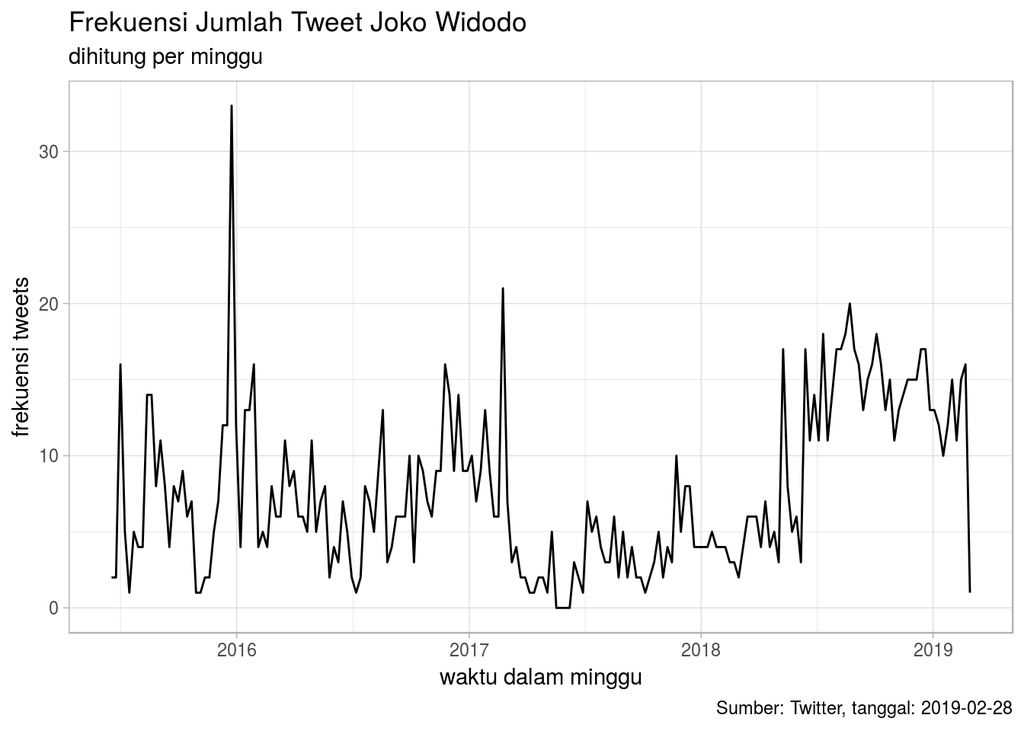

```r
timeline_jokowi %>%
  ts_plot("weeks") +
  theme_light() +
  labs(
    x = "waktu dalam minggu",
    y = "frekuensi tweets",
    title = "Frekuensi Jumlah Tweet Joko Widodo",
    subtitle = "dihitung per minggu",
    caption = paste0("Sumber: Twitter, tanggal: ", Sys.Date())
  )
```

**Frekuensi Tweet Prabowo Subianto Per Minggu**

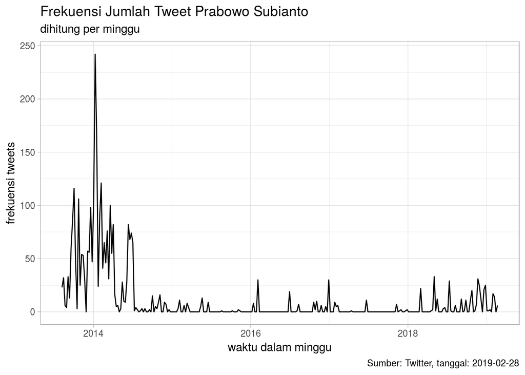

```r
timeline_prabowo %>%
  ts_plot("weeks") +
  theme_light() +
  labs(
    x = "waktu dalam minggu",
    y = "frekuensi tweets",
    title = "Frekuensi Jumlah Tweet Prabowo Subianto",
    subtitle = "dihitung per minggu",
    caption = paste0("Sumber: Twitter, tanggal: ", Sys.Date())
  )
```

Selanjutnya kita akan mencari tahu seberapa banyak pengikut (*follower*) dari masing-masing capres dengan menggunakan fungsi `lookup_users()` lalu memplot hasilnya menggunakan `ggplot2`:

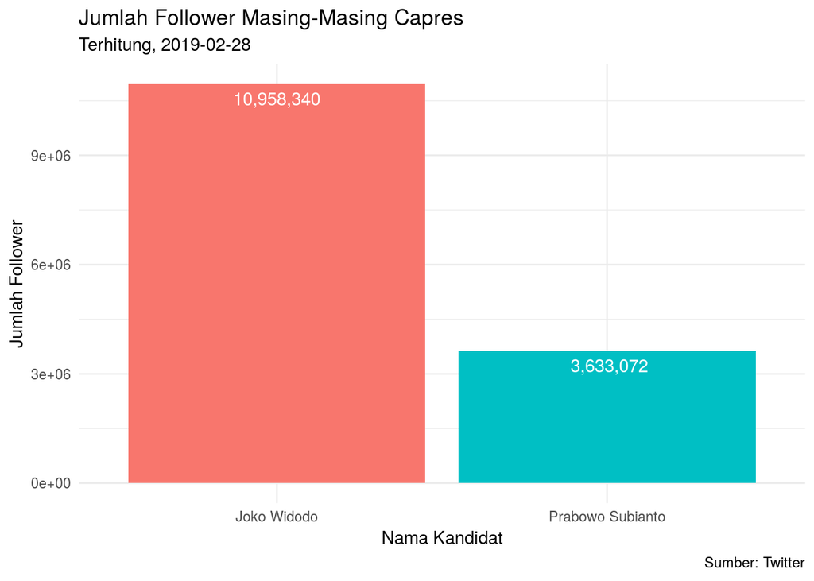

```r
# Ambil informasi jokowi
bio_jokowi <- lookup_users("jokowi")
# Ambil informasi prabowo
bio_prabowo <- lookup_users("prabowo")

# Buat vektor jumlah_follower
jumlah_follower <- c(bio_jokowi$followers_count, bio_prabowo$followers_count)
# Buat vektor nama_kandidat
nama_kandidat <- c("Joko Widodo", "Prabowo Subianto")

data_frame(nama_kandidat, jumlah_follower) %>%
  ggplot(aes(x = nama_kandidat,
             y = jumlah_follower,
             fill = nama_kandidat)) +
  geom_col() +
  geom_text(aes(label = format(jumlah_follower,
                               big.mark = ",")),
            vjust = 1.6, color = "white") +
  theme_minimal() +
  labs(
    x = "Nama Kandidat",
    y = "Jumlah Follower",
    title = "Jumlah Follower Masing-Masing Capres",
    subtitle = paste0("Terhitung, ", Sys.Date()),
    caption = "Sumber: Twitter") +
  theme(legend.title = element_blank(),legend.position = "none")
```